# 2.1.1 A549 LOY vs sgCTRL — RNA-seq base analysis

# Overview

A549 **LOY vs sgCTRL** RNA-seq analysis (AUG 2025 batch — reprocessed under the standardized STAR two-pass + featureCounts v2.1.1 / GENCODE v49 pipeline). A549 is a lung adenocarcinoma line carrying activating **KRAS G12S** with a **p53-null / CDKN2A-deleted** background. LOY was generated by transient nucleofection of a Y-chromosome-targeting sgRNA; sgCTRL is the matched non-targeting sgRNA control; PARENTAL is the unmodified parental population. Replicate counts are unbalanced (4 / 4 / 3 for CTRL / LOY / PARENTAL).

**Design.** PARENTAL samples are retained in the DGEList (gene filtering, TMM, PCA-all-samples, dispersion estimation) but are **excluded from the contrast**: the differential expression test is strictly `LOY − CTRL`. After dropping PARENTAL the LOY+CTRL DE working set has balanced 4-vs-4 replicates, so the paired DE model (`~ 0 + treatment + passage`) is well-defined.

Every figure is saved to `figures_LOY_sgCTRL/` as both PNG (for iterative review) and PDF (for publication).

**Counts pipeline.** Counts come from `STAR_v2_PARfix/AUG_2025_A549_LOY/` — a PAR-Y-masked STAR realignment + featureCounts re-quantification done specifically to recover chrX-PAR reads that the original AUG_2025 STAR run silently dropped at multi-mapper filtering. MSY (true chrY) counts are unchanged; PAR1/PAR2 counts (SHOX, CSF2RA, SLC25A6, etc.) are now non-zero. Y-region annotation lives in §2.1.5; the Y/PAR-retaining volcano is §3.5.

| Group | Samples | Y Status | Role |
| --- | --- | --- | --- |
| CTRL | 4 (rep 1, 2, 3, 4) | Y+ | sgRNA control (reference for the LOY-vs-sgCTRL contrast) |
| PARENTAL | 3 (rep 1, 2, 3) | Y+ | Untreated; variance-estimation only, not in the contrast |
| LOY | 4 (rep 1, 2, 3, 4) | Y− | Y chromosome deleted |

# 1. Setup

## 1.1 Load Packages

## 1.2 Paths, Parameters, and PNG-First Figure Helper

## 1.3 Auto-generate Sample Metadata from Filenames

A549 Sample Summary

| treatment | n | replicates | y_status |
| --- | --- | --- | --- |
| CTRL | 4 | 1, 2, 3, 4 | Y+ |
| LOY | 4 | 1, 2, 3, 4 | Y- |
| PARENTAL | 3 | 1, 2, 3 | Y+ |

## 1.4 Load Count Data

```
## Loading 11 A549 count files from
##    A:/Dropbox/LOY_paralogs/projects/RNAseq/counts/STAR_v2_PARfix/AUG_2025_A549_LOY
```

```
## Loaded 78899 genes across 11 samples
```

# 2. QC: DGEList, Filter, TMM

## 2.1 Build DGEList (2-level treatment factor)

```
## Removing 54543 genes without full annotation
```

```
## Genes remaining: 24356
```

## 2.1.5 Y-region annotation (PAR1 / PAR2 / MSY-Yp / MSY-Yq)

GRCh38 PAR coordinates (Ensembl/GENCODE). PAR genes are annotated on chrX only (chrY PAR positions are masked at the annotation level), so PAR identification scans chrX. MSY = remaining chrY genes (non-PAR), split into Yp / Yq by the chrY centromere midpoint (~10.43 Mb, UCSC).

Two filter sets are exposed downstream:

- **`chrY_gene_ids`** (MSY only) is stripped from the DGEList before differential expression. PAR genes stay in `dge_lc` so they get logFC + FDR values like any other gene — useful for the §3.5 Y-region volcano and for §11-style per-gene PAR summaries.
- **`excluded_gene_ids`** (chrY ∪ PAR) is stripped from pathway-analysis inputs (fgsea ranks, camera, decoupleR ULM, DoRothEA, GSVA / ssGSEA, PROGENy, msVIPER). PAR contamination of those ranks is library-composition artefact (LOY samples lose the chrY-PAR copy), not pathway biology. Filtering happens inside `prep_ranks_t()` (which then cascades to every fgsea-derived pathway call) plus at each gene-symbol-keyed matrix-input call site (decoupleR / GSVA / PROGENy).

```
## Y-region panel: 113 genes  [PAR1=20, PAR2=3, MSY-Yp=35, MSY-Yq=55]
```

```
## Exclusion set for pathway analyses: 113 genes (chrY ∪ PAR)
```

## 2.2 Filter Low-Expressed Genes

```
## Before filtering: 24356
```

```
## After filtering:  14739
```

## 2.3 TMM Normalization

Library sizes and normalization factors

|  | treatment | passage | lib.size | norm.factors | lib.size_M | effective_lib |
| --- | --- | --- | --- | --- | --- | --- |
| A549-CTRL-1 | CTRL | 1 | 52260435 | 0.9185780 | 52.3 | 48.0 |
| A549-CTRL-2 | CTRL | 2 | 57719532 | 1.0069328 | 57.7 | 58.1 |
| A549-CTRL-3 | CTRL | 3 | 62027008 | 1.0031011 | 62.0 | 62.2 |
| A549-CTRL-4 | CTRL | 4 | 62103209 | 1.0395303 | 62.1 | 64.6 |
| A549-LOY-1 | LOY | 1 | 56847552 | 0.9793426 | 56.8 | 55.7 |
| A549-LOY-2 | LOY | 2 | 62218487 | 1.0283625 | 62.2 | 64.0 |
| A549-LOY-3 | LOY | 3 | 59227108 | 0.9896372 | 59.2 | 58.6 |
| A549-LOY-4 | LOY | 4 | 53436226 | 0.9950749 | 53.4 | 53.2 |
| A549-PARENTAL-1 | PARENTAL | 1 | 56191121 | 0.9698785 | 56.2 | 54.5 |
| A549-PARENTAL-2 | PARENTAL | 2 | 59427474 | 1.0844211 | 59.4 | 64.4 |
| A549-PARENTAL-3 | PARENTAL | 3 | 66615889 | 0.9939709 | 66.6 | 66.2 |

## 2.4 PCA

### All samples — PC1 vs PC2

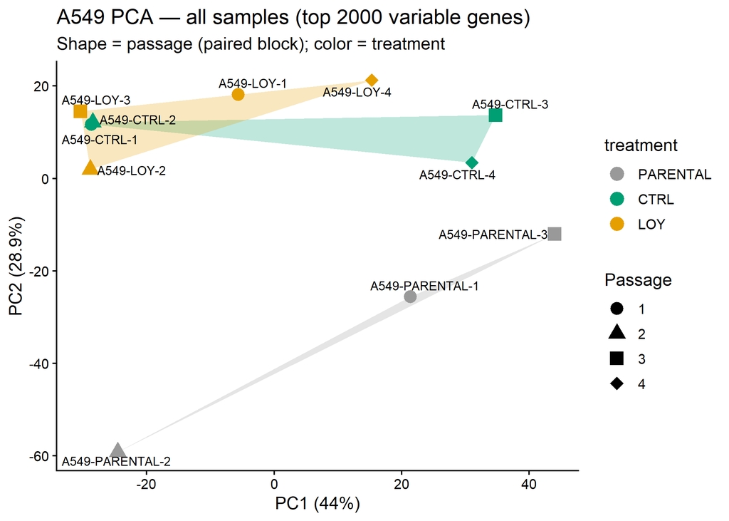

```
## Saved: pca_pc1_pc2.(png|pdf)  [7x5 in]
```

### All samples — PC1 vs PC3

PC2 is often dominated by passage drift. PC3 may resolve treatment biology more cleanly once passage variance is partitioned out.

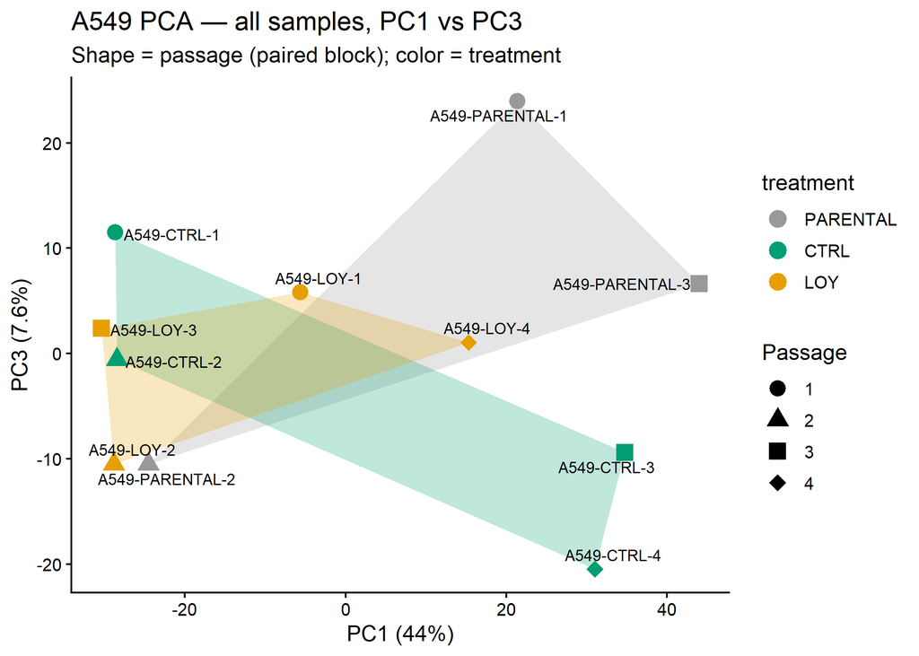

```
## Saved: pca_pc1_pc3.(png|pdf)  [7x5 in]
```

### LOY vs sgCTRL only — PC1 vs PC2

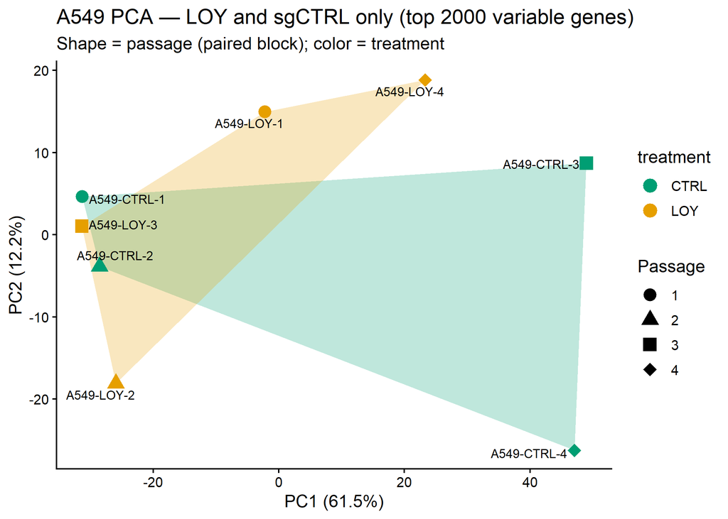

```
## Saved: pca_loy_ctrl_pc1_pc2.(png|pdf)  [7x5 in]
```

### LOY vs sgCTRL only — PC1 vs PC3

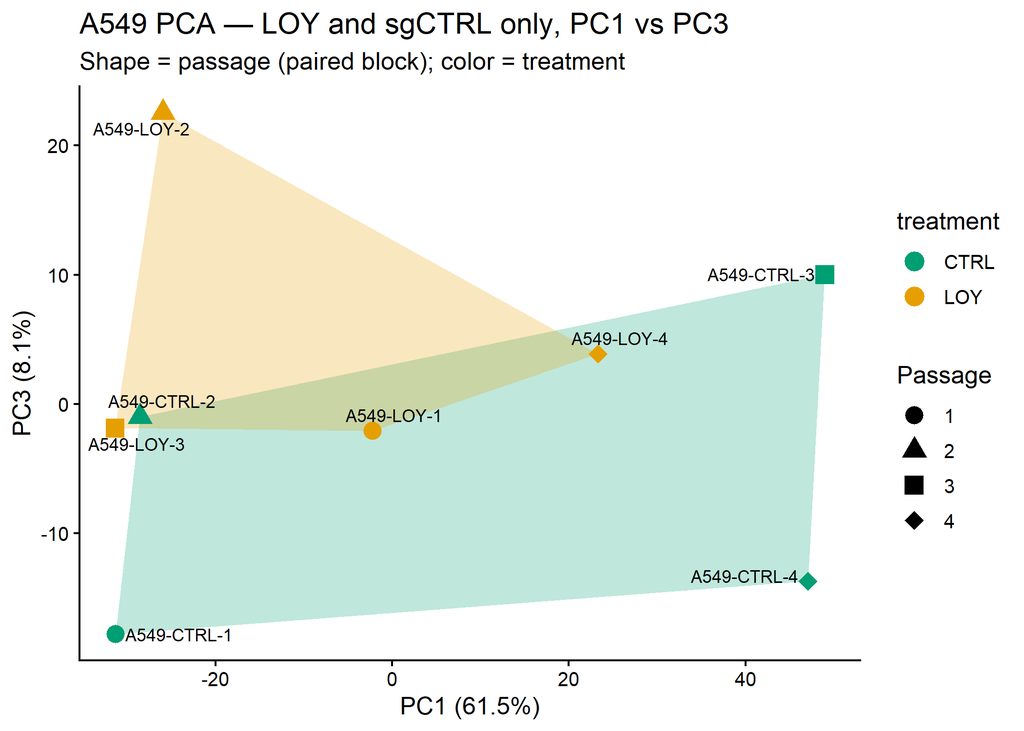

```
## Saved: pca_loy_ctrl_pc1_pc3.(png|pdf)  [7x5 in]
```

## 2.5 Sample distance heatmap

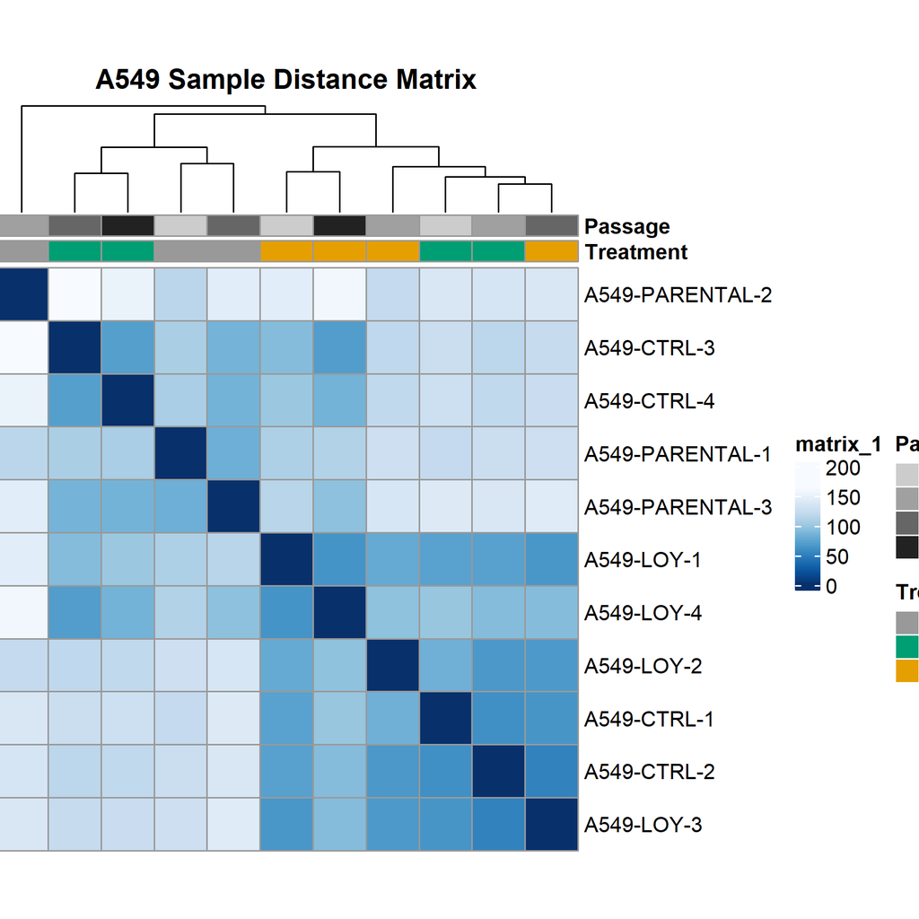

# 3. Y Chromosome Expression

Sanity check: LOY samples should show markedly lower expression of Y-chromosome protein-coding genes than sgCTRL.

```
## Y chromosome genes in data: 9 / 53
```

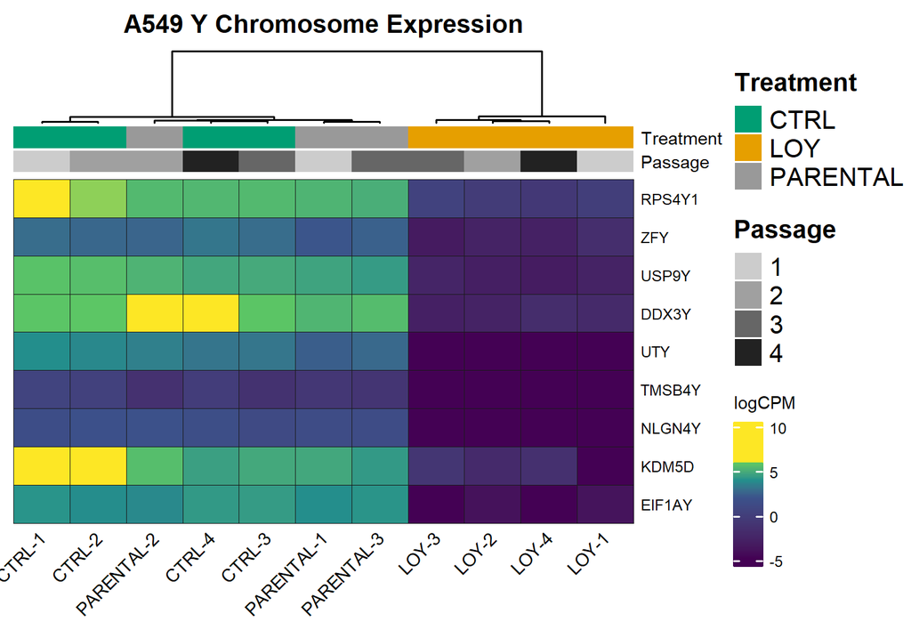

## 3.2 Per-sample summary + key paralogs

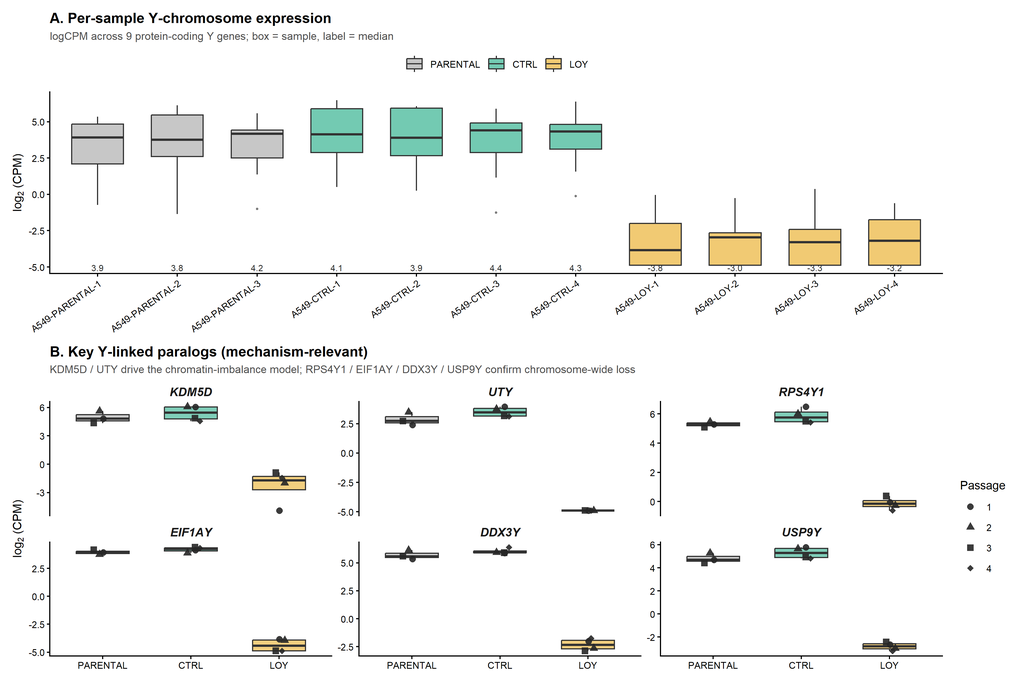

```
## Saved: y_chromosome_summary_and_paralogs.(png|pdf)  [12x8 in]
```

# 3.5 Y-region volcano (pre-strip)

A LOY-vs-sgCTRL paired DE run on a **Y-retaining and PAR-retaining** working set. Every chrY (MSY-Yp / MSY-Yq) and chrX-PAR (PAR1 / PAR2) gene that passes filterByExpr appears here with a real `logFC` + `FDR` value — so the volcano shows exactly *what* the LOY perturbation does to the Y-linked + PAR expression landscape before §4 strips those genes for pathway analysis.

This view was previously impossible because the upstream STAR pipeline dropped PAR multi-mappers (all PAR genes had ~0 reads). Now that `STAR_v2_PARfix` counts are loaded (see §1.2), PAR genes are present and testable.

```
##
## Y-retaining paired DE: 14739 genes tested
```

```
##   Y-region genes with FDR/logFC: 25  [PAR1=14, PAR2=2, MSY-Yp=2, MSY-Yq=7]
```

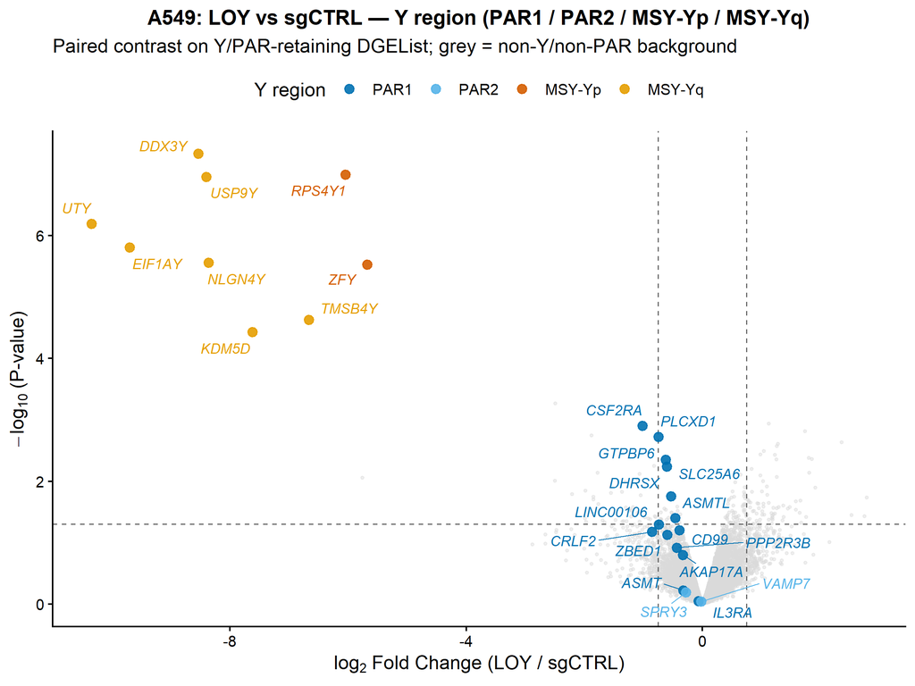

```
## Saved: volcano_LOY_v_sgCTRL_yregion.(png|pdf)  [8x6 in]
```

# 4. Differential Expression: LOY vs sgCTRL

Two designs are fit on `dge_lc` (chrY MSY genes removed, PAR genes retained, TMM recalculated — see §2.1.5 for the split policy): **paired** (treatment + passage) is the recommended primary analysis; **unpaired** is shown for reference. PAR genes get logFC + FDR like every other gene and appear in the volcanos below. Downstream GSEA in §5+ excludes PAR genes at the rank boundary via `prep_ranks_t()`. The Y-region landscape on a Y/PAR-retaining DGEList is in §3.5.

```
## Removing 9 chrY (MSY) genes
```

```
## DE working set: 8 samples (CTRL/LOY)
```

## Paired (treatment + passage)

Design: `~ 0 + treatment + passage`. Passage covariate absorbs per-passage drift before the `LOY - CTRL` contrast.

```
## Design columns: CTRL, LOY, passage2, passage3, passage4
```

```
##
## Paired DE — LOY vs sgCTRL: 14730 genes tested
```

```
##   FDR < 0.05:              0
```

```
##   FDR < 0.05 & |logFC| > 0.75:  0 (up: 0, down: 0)
```

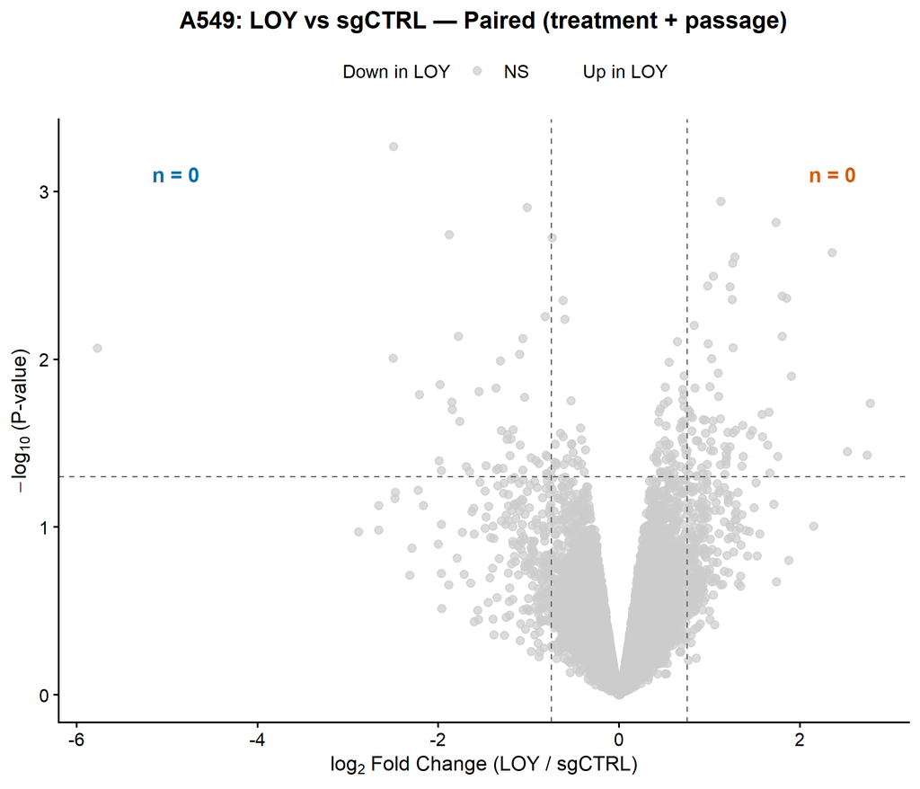

```
## Saved: volcano_LOY_v_sgCTRL_paired.(png|pdf)  [7x6 in]
```

## Unpaired (treatment only)

Design: `~ 0 + treatment`. Passage drift not modeled — reference for what the statistics look like without the covariate.

```
## Design columns: CTRL, LOY
```

```
##
## Unpaired DE — LOY vs sgCTRL: 14730 genes tested
```

```
##   FDR < 0.05:              0
```

```
##   FDR < 0.05 & |logFC| > 0.75:  0 (up: 0, down: 0)
```

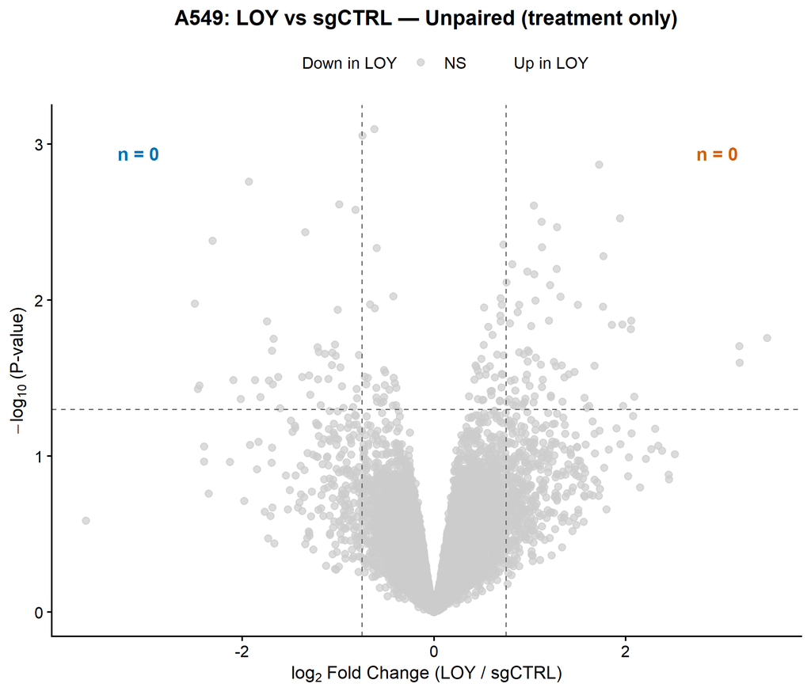

```
## Saved: volcano_LOY_v_sgCTRL_unpaired.(png|pdf)  [7x6 in]
```

# 5. GSEA (Basic Collections)

## 5.1 Setup: ranks + basic pathways

```
## Loading basic MSigDB collections...
```

```
##   hallmark: 50 gene sets
##   reactome: 1787 gene sets
##   kegg: 186 gene sets
##   go_bp: 7583 gene sets
```

## 5.2 Build ranks (RPS/RPL filtered)

```
## Ranked gene list: 14711 genes
```

```
## Removing 91 ribosomal protein genes (RPS/RPL)
```

```
## After RPS/RPL filter: 14620 genes
```

## 5.3 Run fgsea and save

```
## Running fgsea (basic collections) for LOY vs sgCTRL...
```

```
##   Running hallmark (50 gene sets)...
```

```
##   Running reactome (1787 gene sets)...
```

```
##   Running kegg (186 gene sets)...
```

```
##   Running go_bp (7583 gene sets)...
```

## 5.4 Summary

LOY vs sgCTRL — Significant pathways by collection

| collection | total | sig_up | sig_down |
| --- | --- | --- | --- |
| go_bp | 3638 | 156 | 131 |
| hallmark | 50 | 6 | 12 |
| kegg | 161 | 3 | 3 |
| reactome | 1001 | 27 | 189 |

## 5.5 Publication dotplot

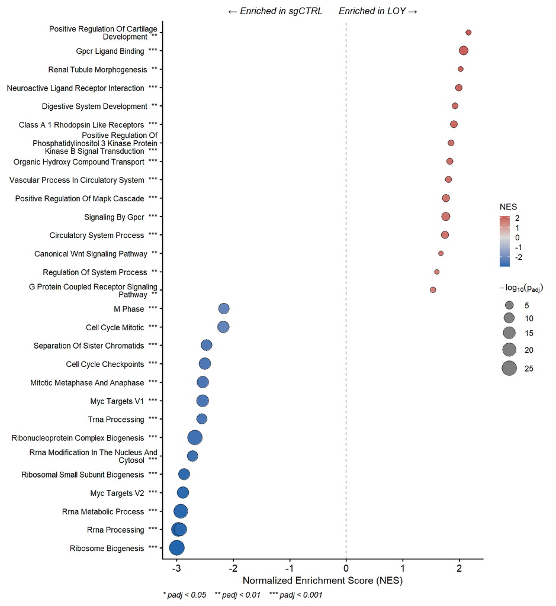

```
## Saved: gsea_dotplot_basic.(png|pdf)  [5.5x6 in]
```

## 5.6 Top Hallmark enrichment plots

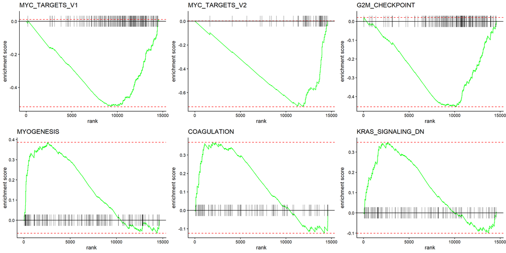

```
## Saved: gsea_enrichment_top_hallmark.(png|pdf)  [12x6 in]
```

# 6. GSEA (Expanded: +CGP, +CP subsets)

## 6.1 Load expanded collections

```
## Loading expanded MSigDB collections...
```

```
##   hallmark: 50 gene sets
##   c2_all: 7561 gene sets
##   cgp: 3538 gene sets
##   cp: 19 gene sets
##   cp_biocarta: 292 gene sets
##   cp_kegg_med: 658 gene sets
##   cp_pid: 196 gene sets
##   cp_reactome: 1787 gene sets
##   cp_wikipath: 885 gene sets
##   cp_kegg_leg: 186 gene sets
```

## 6.2 Run expanded fgsea

```
## Running fgsea (expanded) for LOY vs sgCTRL...
```

```
##   Running hallmark (50 gene sets)...
```

```
##   Running c2_all (7561 gene sets)...
```

```
##   Running cgp (3538 gene sets)...
```

```
##   Running cp (19 gene sets)...
```

```
##   Running cp_biocarta (292 gene sets)...
```

```
##   Running cp_kegg_med (658 gene sets)...
```

```
##   Running cp_pid (196 gene sets)...
```

```
##   Running cp_reactome (1787 gene sets)...
```

```
##   Running cp_wikipath (885 gene sets)...
```

```
##   Running cp_kegg_leg (186 gene sets)...
```

## 6.3 Expanded summary

LOY vs sgCTRL (expanded) — Significant pathways by collection

| collection | total | sig_up | sig_down |
| --- | --- | --- | --- |
| c2_all | 4839 | 212 | 529 |
| cgp | 2601 | 172 | 304 |
| cp | 13 | 0 | 0 |
| cp_biocarta | 113 | 1 | 0 |
| cp_kegg_leg | 161 | 1 | 3 |
| cp_kegg_med | 203 | 1 | 10 |
| cp_pid | 177 | 1 | 7 |
| cp_reactome | 1001 | 27 | 180 |
| cp_wikipath | 570 | 6 | 9 |
| hallmark | 50 | 6 | 12 |

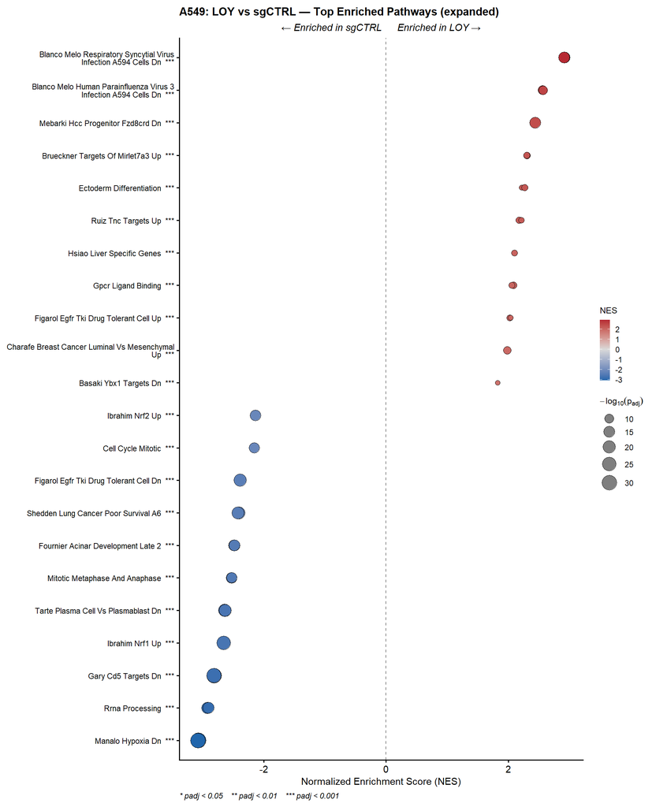

```
## Saved: gsea_dotplot_expanded.(png|pdf)  [6.5x8 in]
```

## 6.5 CGP-only dotplot

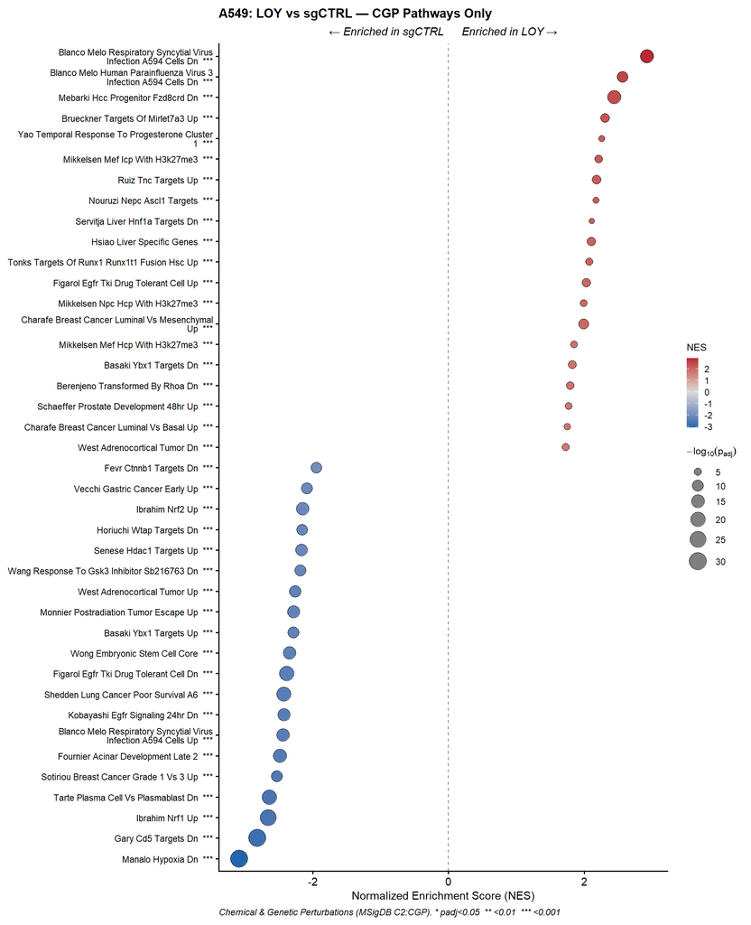

```
## Saved: gsea_dotplot_cgp.(png|pdf)  [6.5x8 in]
```

```
##
## Top 15 CGP pathways (by p-value):
```

LOY vs sgCTRL — Top 15 CGP pathways

| pathway | NES | pval | padj | size |
| --- | --- | --- | --- | --- |
| GARY_CD5_TARGETS_DN | -2.814868 | 0 | 0 | 400 |
| MANALO_HYPOXIA_DN | -3.078772 | 0 | 0 | 267 |
| IBRAHIM_NRF1_UP | -2.652854 | 0 | 0 | 398 |
| TARTE_PLASMA_CELL_VS_PLASMABLAST_DN | -2.636185 | 0 | 0 | 277 |
| FIGAROL_EGFR_TKI_DRUG_TOLERANT_CELL_DN | -2.383392 | 0 | 0 | 484 |
| SHEDDEN_LUNG_CANCER_POOR_SURVIVAL_A6 | -2.420121 | 0 | 0 | 417 |
| BLANCO_MELO_RESPIRATORY_SYNCYTIAL_VIRUS_INFECTION_A594_CELLS_DN | 2.920668 | 0 | 0 | 106 |
| FOURNIER_ACINAR_DEVELOPMENT_LATE_2 | -2.480743 | 0 | 0 | 273 |
| MEBARKI_HCC_PROGENITOR_FZD8CRD_DN | 2.440788 | 0 | 0 | 302 |
| WONG_EMBRYONIC_STEM_CELL_CORE | -2.338316 | 0 | 0 | 305 |
| BLANCO_MELO_RESPIRATORY_SYNCYTIAL_VIRUS_INFECTION_A594_CELLS_UP | -2.432469 | 0 | 0 | 258 |
| IBRAHIM_NRF2_UP | -2.144715 | 0 | 0 | 492 |
| MONNIER_POSTRADIATION_TUMOR_ESCAPE_UP | -2.277843 | 0 | 0 | 364 |
| KOBAYASHI_EGFR_SIGNALING_24HR_DN | -2.423377 | 0 | 0 | 244 |
| SENESE_HDAC1_TARGETS_UP | -2.162680 | 0 | 0 | 391 |

# 7. Chromatin / PRC2 Deep Dive

## 7.1 Chromatin pathway dotplot

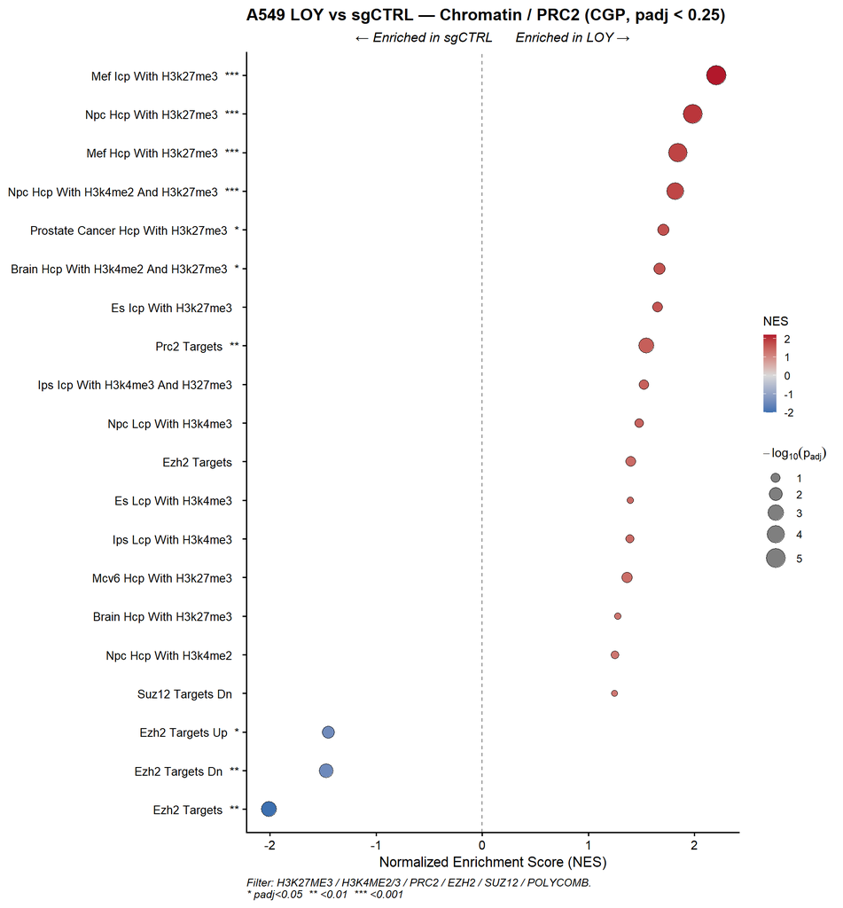

```
## Saved: gsea_dotplot_chromatin.(png|pdf)  [6.5x7 in]
##
## Chromatin pathways at padj < 0.05:
```

A549 LOY vs sgCTRL — significant chromatin pathways

| pathway | NES | pval | padj | size |
| --- | --- | --- | --- | --- |
| MIKKELSEN_MEF_ICP_WITH_H3K27ME3 | 2.209474 | 0.0000001 | 0.0000051 | 96 |
| MIKKELSEN_NPC_HCP_WITH_H3K27ME3 | 1.984368 | 0.0000005 | 0.0000142 | 176 |
| MIKKELSEN_MEF_HCP_WITH_H3K27ME3 | 1.845092 | 0.0000006 | 0.0000169 | 274 |
| MEISSNER_NPC_HCP_WITH_H3K4ME2_AND_H3K27ME3 | 1.820063 | 0.0000097 | 0.0001948 | 185 |
| BENPORATH_PRC2_TARGETS | 1.547150 | 0.0001054 | 0.0014736 | 338 |
| KAMMINGA_EZH2_TARGETS | -2.009265 | 0.0001417 | 0.0019004 | 38 |
| LU_EZH2_TARGETS_DN | -1.469242 | 0.0004652 | 0.0048467 | 345 |
| LU_EZH2_TARGETS_UP | -1.450487 | 0.0029373 | 0.0217660 | 239 |
| MEISSNER_BRAIN_HCP_WITH_H3K4ME2_AND_H3K27ME3 | 1.669253 | 0.0051555 | 0.0329469 | 38 |
| KONDO_PROSTATE_CANCER_HCP_WITH_H3K27ME3 | 1.706788 | 0.0053850 | 0.0338321 | 65 |

## 7.2 Enrichment curves for top chromatin pathways

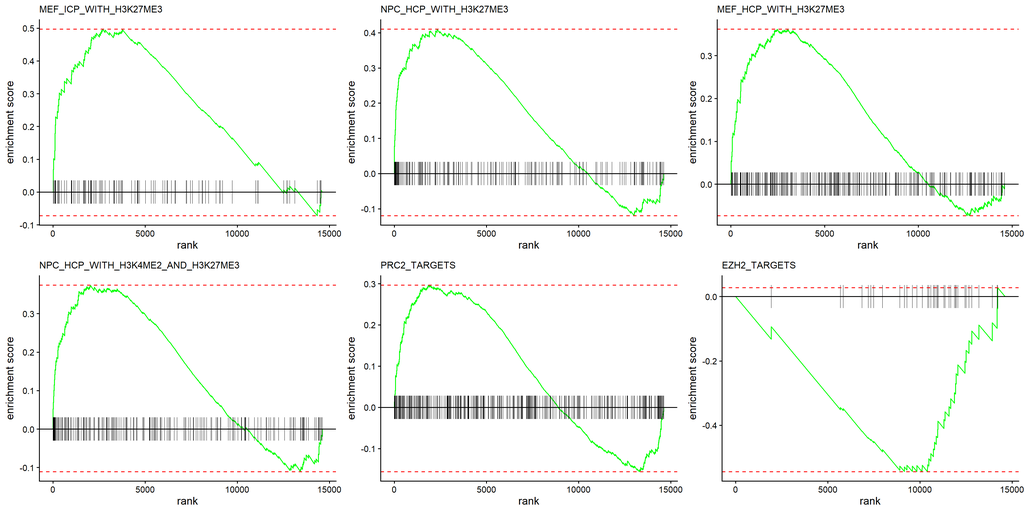

```
## Saved: gsea_enrichment_chromatin.(png|pdf)  [12x6 in]
```

## 7.3 H3K27me3 target gene volcano

Highlight `MIKKELSEN_MEF_HCP_WITH_H3K27ME3` member genes (bivalent-promoter developmental regulators carrying H3K27me3 in MEFs) on the full DE volcano.

```
## H3K27me3 set genes in DE: 275
##   nom. p < 0.05 & up:   9
##   nom. p < 0.05 & down: 1
```

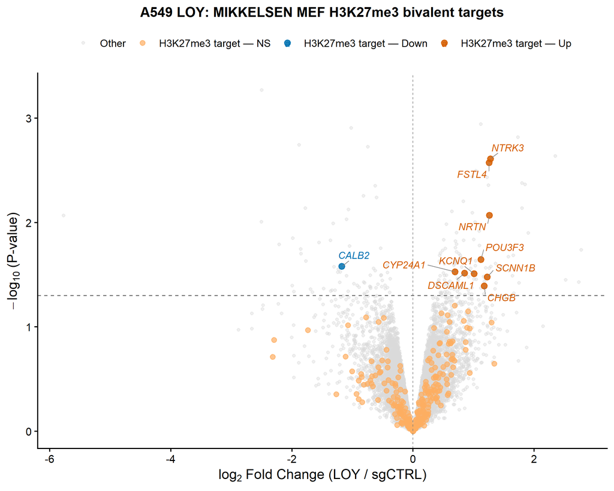

```
## Saved: volcano_h3k27me3_targets.(png|pdf)  [7.5x6 in]
```